# Risk Factor Analysis

## Outcome Variable

**Outcome Variable:** y_rate_len

## Predictor Variables

**Intervention Variable:** predfeed3

**Adjustment Set:**

unadjusted

## Stratifying Variables

The analysis was stratified on these variable(s):

- agecat
- studyid
- country

## Data Summary

| agecat | studyid | country | predfeed3 | n_cell | n |
| --- | --- | --- | --- | --- | --- |
| 0-3 months | ki0047075b-MAL-ED | BANGLADESH | 0 | 35 | 239 |
| 0-3 months | ki0047075b-MAL-ED | BANGLADESH | 1 | 204 | 239 |
| 0-3 months | ki0047075b-MAL-ED | BRAZIL | 0 | 80 | 180 |
| 0-3 months | ki0047075b-MAL-ED | BRAZIL | 1 | 100 | 180 |
| 0-3 months | ki0047075b-MAL-ED | INDIA | 0 | 46 | 199 |
| 0-3 months | ki0047075b-MAL-ED | INDIA | 1 | 153 | 199 |
| 0-3 months | ki0047075b-MAL-ED | NEPAL | 0 | 73 | 175 |
| 0-3 months | ki0047075b-MAL-ED | NEPAL | 1 | 102 | 175 |
| 0-3 months | ki0047075b-MAL-ED | PERU | 0 | 89 | 268 |
| 0-3 months | ki0047075b-MAL-ED | PERU | 1 | 179 | 268 |
| 0-3 months | ki0047075b-MAL-ED | SOUTH AFRICA | 0 | 140 | 226 |
| 0-3 months | ki0047075b-MAL-ED | SOUTH AFRICA | 1 | 86 | 226 |
| 0-3 months | ki0047075b-MAL-ED | TANZANIA, UNITED REPUBLIC OF | 0 | 145 | 224 |
| 0-3 months | ki0047075b-MAL-ED | TANZANIA, UNITED REPUBLIC OF | 1 | 79 | 224 |
| 0-3 months | ki1000109-EE | PAKISTAN | 0 | 32 | 592 |
| 0-3 months | ki1000109-EE | PAKISTAN | 1 | 560 | 592 |
| 0-3 months | kiGH5241-JiVitA-3 | BANGLADESH | 0 | 4246 | 39314 |
| 0-3 months | kiGH5241-JiVitA-3 | BANGLADESH | 1 | 35068 | 39314 |
| 0-3 months | kiGH5241-JiVitA-4 | BANGLADESH | 0 | 20 | 242 |
| 0-3 months | kiGH5241-JiVitA-4 | BANGLADESH | 1 | 222 | 242 |
| 3-6 months | ki0047075b-MAL-ED | BANGLADESH | 0 | 33 | 227 |
| 3-6 months | ki0047075b-MAL-ED | BANGLADESH | 1 | 194 | 227 |
| 3-6 months | ki0047075b-MAL-ED | BRAZIL | 0 | 92 | 208 |
| 3-6 months | ki0047075b-MAL-ED | BRAZIL | 1 | 116 | 208 |
| 3-6 months | ki0047075b-MAL-ED | INDIA | 0 | 53 | 229 |
| 3-6 months | ki0047075b-MAL-ED | INDIA | 1 | 176 | 229 |
| 3-6 months | ki0047075b-MAL-ED | NEPAL | 0 | 101 | 232 |
| 3-6 months | ki0047075b-MAL-ED | NEPAL | 1 | 131 | 232 |
| 3-6 months | ki0047075b-MAL-ED | PERU | 0 | 84 | 265 |
| 3-6 months | ki0047075b-MAL-ED | PERU | 1 | 181 | 265 |

[output cut: 54 more lines]

The following strata were considered:

- agecat: 0-3 months, studyid: ki0047075b-MAL-ED, country: BANGLADESH
- agecat: 0-3 months, studyid: ki0047075b-MAL-ED, country: BRAZIL
- agecat: 0-3 months, studyid: ki0047075b-MAL-ED, country: INDIA
- agecat: 0-3 months, studyid: ki0047075b-MAL-ED, country: NEPAL
- agecat: 0-3 months, studyid: ki0047075b-MAL-ED, country: PERU
- agecat: 0-3 months, studyid: ki0047075b-MAL-ED, country: SOUTH AFRICA
- agecat: 0-3 months, studyid: ki0047075b-MAL-ED, country: TANZANIA, UNITED REPUBLIC OF
- agecat: 0-3 months, studyid: ki1000109-EE, country: PAKISTAN
- agecat: 0-3 months, studyid: kiGH5241-JiVitA-3, country: BANGLADESH
- agecat: 0-3 months, studyid: kiGH5241-JiVitA-4, country: BANGLADESH
- agecat: 12-24 months, studyid: ki0047075b-MAL-ED, country: BANGLADESH
- agecat: 12-24 months, studyid: ki0047075b-MAL-ED, country: BRAZIL
- agecat: 12-24 months, studyid: ki0047075b-MAL-ED, country: INDIA
- agecat: 12-24 months, studyid: ki0047075b-MAL-ED, country: NEPAL
- agecat: 12-24 months, studyid: ki0047075b-MAL-ED, country: PERU
- agecat: 12-24 months, studyid: ki0047075b-MAL-ED, country: SOUTH AFRICA
- agecat: 12-24 months, studyid: ki0047075b-MAL-ED, country: TANZANIA, UNITED REPUBLIC OF
- agecat: 12-24 months, studyid: ki1113344-GMS-Nepal, country: NEPAL
- agecat: 12-24 months, studyid: kiGH5241-JiVitA-3, country: BANGLADESH
- agecat: 12-24 months, studyid: kiGH5241-JiVitA-4, country: BANGLADESH
- agecat: 3-6 months, studyid: ki0047075b-MAL-ED, country: BANGLADESH
- agecat: 3-6 months, studyid: ki0047075b-MAL-ED, country: BRAZIL
- agecat: 3-6 months, studyid: ki0047075b-MAL-ED, country: INDIA
- agecat: 3-6 months, studyid: ki0047075b-MAL-ED, country: NEPAL
- agecat: 3-6 months, studyid: ki0047075b-MAL-ED, country: PERU
- agecat: 3-6 months, studyid: ki0047075b-MAL-ED, country: SOUTH AFRICA
- agecat: 3-6 months, studyid: ki0047075b-MAL-ED, country: TANZANIA, UNITED REPUBLIC OF
- agecat: 3-6 months, studyid: ki1000109-EE, country: PAKISTAN
- agecat: 3-6 months, studyid: ki1113344-GMS-Nepal, country: NEPAL
- agecat: 3-6 months, studyid: kiGH5241-JiVitA-3, country: BANGLADESH
- agecat: 3-6 months, studyid: kiGH5241-JiVitA-4, country: BANGLADESH
- agecat: 6-12 months, studyid: ki0047075b-MAL-ED, country: BANGLADESH
- agecat: 6-12 months, studyid: ki0047075b-MAL-ED, country: BRAZIL
- agecat: 6-12 months, studyid: ki0047075b-MAL-ED, country: INDIA
- agecat: 6-12 months, studyid: ki0047075b-MAL-ED, country: NEPAL
- agecat: 6-12 months, studyid: ki0047075b-MAL-ED, country: PERU
- agecat: 6-12 months, studyid: ki0047075b-MAL-ED, country: SOUTH AFRICA
- agecat: 6-12 months, studyid: ki0047075b-MAL-ED, country: TANZANIA, UNITED REPUBLIC OF
- agecat: 6-12 months, studyid: ki1000109-EE, country: PAKISTAN
- agecat: 6-12 months, studyid: ki1113344-GMS-Nepal, country: NEPAL
- agecat: 6-12 months, studyid: kiGH5241-JiVitA-3, country: BANGLADESH
- agecat: 6-12 months, studyid: kiGH5241-JiVitA-4, country: BANGLADESH

### Dropped Strata

Some strata were dropped due to rare outcomes:

- agecat: 3-6 months, studyid: kiGH5241-JiVitA-4, country: BANGLADESH
- agecat: 6-12 months, studyid: ki1000109-EE, country: PAKISTAN
- agecat: 6-12 months, studyid: kiGH5241-JiVitA-4, country: BANGLADESH

## Methods Detail

We’re interested in the causal parameters $E[Y_a]$ for all values of $a \in \mathcal{A}$. These parameters represent the mean outcome if, possibly contrary to fact, we intervened to set all units to have $A=a$. Under the randomization and positivity assumptions, these are identified by the statistical parameters $\psi_a=E_W[E_{Y|A,W}(Y|A=a,W)]$. In addition, we’re interested in the mean of $Y$, $E[Y]$ under no intervention (the observed mean). We will estimate these parameters by using SuperLearner to fit the relevant likelihood factors – $E_{Y|A,W}(Y|A=a,W)$ and $p(A=a|W)$, and then updating our likelihood fit using a joint TMLE.

For unadjusted analyses ($W=\{\}$), initial likelihoods were estimated using Lrnr_glm to estimate the simple $E(Y|A)$ and Lrnr_mean to estimate $p(A)$. For adjusted analyses, a small library containing Lrnr_glmnet, Lrnr_xgboost, and Lrnr_mean was used.

# Results Detail

## Results Plots

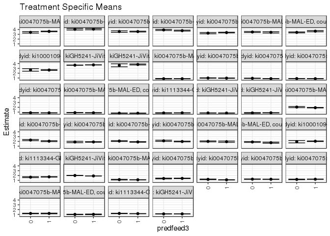

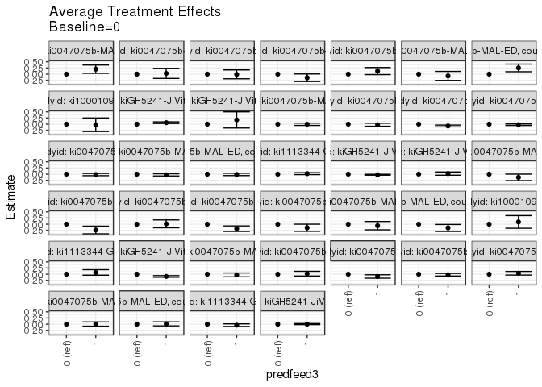

## Results Table

### Parameter: TSM

| agecat | studyid | country | intervention_level | baseline_level | estimate | ci_lower | ci_upper |
| --- | --- | --- | --- | --- | --- | --- | --- |
| 0-3 months | ki0047075b-MAL-ED | BANGLADESH | 0 | NA | 3.3966348 | 3.2429546 | 3.5503149 |
| 0-3 months | ki0047075b-MAL-ED | BANGLADESH | 1 | NA | 3.5971925 | 3.5284943 | 3.6658907 |
| 0-3 months | ki0047075b-MAL-ED | BRAZIL | 0 | NA | 4.0344157 | 3.8802058 | 4.1886255 |
| 0-3 months | ki0047075b-MAL-ED | BRAZIL | 1 | NA | 4.0642160 | 3.9289608 | 4.1994711 |
| 0-3 months | ki0047075b-MAL-ED | INDIA | 0 | NA | 3.5736379 | 3.4156791 | 3.7315966 |
| 0-3 months | ki0047075b-MAL-ED | INDIA | 1 | NA | 3.5636935 | 3.4762273 | 3.6511597 |
| 0-3 months | ki0047075b-MAL-ED | NEPAL | 0 | NA | 3.9069501 | 3.7874855 | 4.0264148 |
| 0-3 months | ki0047075b-MAL-ED | NEPAL | 1 | NA | 3.7586177 | 3.6617791 | 3.8554564 |
| 0-3 months | ki0047075b-MAL-ED | PERU | 0 | NA | 3.2344034 | 3.1113222 | 3.3574846 |
| 0-3 months | ki0047075b-MAL-ED | PERU | 1 | NA | 3.3580193 | 3.2855866 | 3.4304520 |
| 0-3 months | ki0047075b-MAL-ED | SOUTH AFRICA | 0 | NA | 3.4725503 | 3.3560286 | 3.5890719 |
| 0-3 months | ki0047075b-MAL-ED | SOUTH AFRICA | 1 | NA | 3.3999027 | 3.2585951 | 3.5412104 |
| 0-3 months | ki0047075b-MAL-ED | TANZANIA, UNITED REPUBLIC OF | 0 | NA | 3.3915117 | 3.2924118 | 3.4906116 |
| 0-3 months | ki0047075b-MAL-ED | TANZANIA, UNITED REPUBLIC OF | 1 | NA | 3.6440889 | 3.5243959 | 3.7637819 |
| 0-3 months | ki1000109-EE | PAKISTAN | 0 | NA | 2.6781737 | 2.4165257 | 2.9398218 |
| 0-3 months | ki1000109-EE | PAKISTAN | 1 | NA | 2.6538213 | 2.5665982 | 2.7410444 |
| 0-3 months | kiGH5241-JiVitA-3 | BANGLADESH | 0 | NA | 3.6665275 | 3.6345381 | 3.6985168 |
| 0-3 months | kiGH5241-JiVitA-3 | BANGLADESH | 1 | NA | 3.7256050 | 3.7147277 | 3.7364824 |
| 0-3 months | kiGH5241-JiVitA-4 | BANGLADESH | 0 | NA | 3.6400973 | 3.3271866 | 3.9530079 |
| 0-3 months | kiGH5241-JiVitA-4 | BANGLADESH | 1 | NA | 3.8113327 | 3.7093184 | 3.9133470 |
| 3-6 months | ki0047075b-MAL-ED | BANGLADESH | 0 | NA | 2.0452189 | 1.9240269 | 2.1664109 |
| 3-6 months | ki0047075b-MAL-ED | BANGLADESH | 1 | NA | 1.9141857 | 1.8607835 | 1.9675879 |
| 3-6 months | ki0047075b-MAL-ED | BRAZIL | 0 | NA | 2.2794845 | 2.1572151 | 2.4017540 |
| 3-6 months | ki0047075b-MAL-ED | BRAZIL | 1 | NA | 2.0433885 | 1.9437209 | 2.1430561 |
| 3-6 months | ki0047075b-MAL-ED | INDIA | 0 | NA | 1.8738926 | 1.7299167 | 2.0178685 |
| 3-6 months | ki0047075b-MAL-ED | INDIA | 1 | NA | 1.8866877 | 1.8197675 | 1.9536080 |
| 3-6 months | ki0047075b-MAL-ED | NEPAL | 0 | NA | 2.0684633 | 1.9815985 | 2.1553280 |
| 3-6 months | ki0047075b-MAL-ED | NEPAL | 1 | NA | 1.8863103 | 1.8158977 | 1.9567229 |
| 3-6 months | ki0047075b-MAL-ED | PERU | 0 | NA | 2.1195192 | 1.9969145 | 2.2421238 |
| 3-6 months | ki0047075b-MAL-ED | PERU | 1 | NA | 1.9742886 | 1.8968022 | 2.0517751 |
| 3-6 months | ki0047075b-MAL-ED | SOUTH AFRICA | 0 | NA | 1.9978800 | 1.8969163 | 2.0988438 |
| 3-6 months | ki0047075b-MAL-ED | SOUTH AFRICA | 1 | NA | 1.9376178 | 1.8014237 | 2.0738120 |
| 3-6 months | ki0047075b-MAL-ED | TANZANIA, UNITED REPUBLIC OF | 0 | NA | 1.8853167 | 1.7973766 | 1.9732569 |
| 3-6 months | ki0047075b-MAL-ED | TANZANIA, UNITED REPUBLIC OF | 1 | NA | 1.7317386 | 1.6215296 | 1.8419476 |
| 3-6 months | ki1000109-EE | PAKISTAN | 0 | NA | 1.9408762 | 1.6912610 | 2.1904915 |
| 3-6 months | ki1000109-EE | PAKISTAN | 1 | NA | 2.0312708 | 1.9688785 | 2.0936631 |
| 3-6 months | ki1113344-GMS-Nepal | NEPAL | 0 | NA | 1.6467525 | 1.5453471 | 1.7481578 |
| 3-6 months | ki1113344-GMS-Nepal | NEPAL | 1 | NA | 1.7174264 | 1.6723975 | 1.7624552 |
| 3-6 months | kiGH5241-JiVitA-3 | BANGLADESH | 0 | NA | 2.0014754 | 1.9698377 | 2.0331132 |
| 3-6 months | kiGH5241-JiVitA-3 | BANGLADESH | 1 | NA | 1.9099954 | 1.8991922 | 1.9207987 |
| 6-12 months | ki0047075b-MAL-ED | BANGLADESH | 0 | NA | 1.1395704 | 1.0666940 | 1.2124467 |
| 6-12 months | ki0047075b-MAL-ED | BANGLADESH | 1 | NA | 1.1104070 | 1.0837626 | 1.1370514 |
| 6-12 months | ki0047075b-MAL-ED | BRAZIL | 0 | NA | 1.3746013 | 1.2973039 | 1.4518986 |
| 6-12 months | ki0047075b-MAL-ED | BRAZIL | 1 | NA | 1.3953155 | 1.3388625 | 1.4517684 |
| 6-12 months | ki0047075b-MAL-ED | INDIA | 0 | NA | 1.1925931 | 1.1298053 | 1.2553809 |
| 6-12 months | ki0047075b-MAL-ED | INDIA | 1 | NA | 1.0986498 | 1.0674794 | 1.1298202 |
| 6-12 months | ki0047075b-MAL-ED | NEPAL | 0 | NA | 1.2352913 | 1.1951739 | 1.2754088 |
| 6-12 months | ki0047075b-MAL-ED | NEPAL | 1 | NA | 1.2139146 | 1.1801472 | 1.2476819 |
| 6-12 months | ki0047075b-MAL-ED | PERU | 0 | NA | 1.1829568 | 1.1205519 | 1.2453617 |
| 6-12 months | ki0047075b-MAL-ED | PERU | 1 | NA | 1.2216366 | 1.1832614 | 1.2600119 |
| 6-12 months | ki0047075b-MAL-ED | SOUTH AFRICA | 0 | NA | 1.1933103 | 1.1400555 | 1.2465651 |
| 6-12 months | ki0047075b-MAL-ED | SOUTH AFRICA | 1 | NA | 1.1966594 | 1.1292780 | 1.2640409 |
| 6-12 months | ki0047075b-MAL-ED | TANZANIA, UNITED REPUBLIC OF | 0 | NA | 0.9959031 | 0.9506143 | 1.0411920 |
| 6-12 months | ki0047075b-MAL-ED | TANZANIA, UNITED REPUBLIC OF | 1 | NA | 1.0083737 | 0.9415365 | 1.0752109 |
| 6-12 months | ki1113344-GMS-Nepal | NEPAL | 0 | NA | 1.1971476 | 1.1508458 | 1.2434494 |
| 6-12 months | ki1113344-GMS-Nepal | NEPAL | 1 | NA | 1.1562114 | 1.1316513 | 1.1807714 |
| 6-12 months | kiGH5241-JiVitA-3 | BANGLADESH | 0 | NA | 1.1027982 | 1.0812667 | 1.1243297 |
| 6-12 months | kiGH5241-JiVitA-3 | BANGLADESH | 1 | NA | 1.1063008 | 1.0992399 | 1.1133617 |
| 12-24 months | ki0047075b-MAL-ED | BANGLADESH | 0 | NA | 0.8490741 | 0.8053636 | 0.8927847 |
| 12-24 months | ki0047075b-MAL-ED | BANGLADESH | 1 | NA | 0.8444468 | 0.8270894 | 0.8618042 |
| 12-24 months | ki0047075b-MAL-ED | BRAZIL | 0 | NA | 0.9956321 | 0.9516172 | 1.0396470 |
| 12-24 months | ki0047075b-MAL-ED | BRAZIL | 1 | NA | 0.9715565 | 0.9293385 | 1.0137745 |
| 12-24 months | ki0047075b-MAL-ED | INDIA | 0 | NA | 0.9371244 | 0.9063571 | 0.9678917 |
| 12-24 months | ki0047075b-MAL-ED | INDIA | 1 | NA | 0.8632290 | 0.8432006 | 0.8832574 |
| 12-24 months | ki0047075b-MAL-ED | NEPAL | 0 | NA | 0.8745159 | 0.8506098 | 0.8984220 |
| 12-24 months | ki0047075b-MAL-ED | NEPAL | 1 | NA | 0.8523057 | 0.8326217 | 0.8719897 |
| 12-24 months | ki0047075b-MAL-ED | PERU | 0 | NA | 0.8581038 | 0.8192651 | 0.8969425 |
| 12-24 months | ki0047075b-MAL-ED | PERU | 1 | NA | 0.8418161 | 0.8173167 | 0.8663155 |
| 12-24 months | ki0047075b-MAL-ED | SOUTH AFRICA | 0 | NA | 0.8808888 | 0.8520683 | 0.9097093 |
| 12-24 months | ki0047075b-MAL-ED | SOUTH AFRICA | 1 | NA | 0.8528162 | 0.8175509 | 0.8880815 |
| 12-24 months | ki0047075b-MAL-ED | TANZANIA, UNITED REPUBLIC OF | 0 | NA | 0.7692616 | 0.7375017 | 0.8010214 |
| 12-24 months | ki0047075b-MAL-ED | TANZANIA, UNITED REPUBLIC OF | 1 | NA | 0.7580519 | 0.7228181 | 0.7932857 |
| 12-24 months | ki1113344-GMS-Nepal | NEPAL | 0 | NA | 0.8190084 | 0.7840632 | 0.8539536 |
| 12-24 months | ki1113344-GMS-Nepal | NEPAL | 1 | NA | 0.8398709 | 0.8211137 | 0.8586281 |
| 12-24 months | kiGH5241-JiVitA-3 | BANGLADESH | 0 | NA | 0.8177532 | 0.8013823 | 0.8341240 |
| 12-24 months | kiGH5241-JiVitA-3 | BANGLADESH | 1 | NA | 0.7938546 | 0.7882408 | 0.7994684 |
| 12-24 months | kiGH5241-JiVitA-4 | BANGLADESH | 0 | NA | 0.8286459 | 0.7683653 | 0.8889265 |
| 12-24 months | kiGH5241-JiVitA-4 | BANGLADESH | 1 | NA | 0.8508647 | 0.8271438 | 0.8745856 |

### Parameter: E(Y)

| agecat | studyid | country | intervention_level | baseline_level | estimate | ci_lower | ci_upper |
| --- | --- | --- | --- | --- | --- | --- | --- |
| 0-3 months | ki0047075b-MAL-ED | BANGLADESH | NA | NA | 3.5678222 | 3.5043711 | 3.6312732 |
| 0-3 months | ki0047075b-MAL-ED | BRAZIL | NA | NA | 4.0509714 | 3.9492443 | 4.1526985 |
| 0-3 months | ki0047075b-MAL-ED | INDIA | NA | NA | 3.5659922 | 3.4894688 | 3.6425155 |
| 0-3 months | ki0047075b-MAL-ED | NEPAL | NA | NA | 3.8204935 | 3.7444190 | 3.8965681 |
| 0-3 months | ki0047075b-MAL-ED | PERU | NA | NA | 3.3169678 | 3.2532502 | 3.3806854 |
| 0-3 months | ki0047075b-MAL-ED | SOUTH AFRICA | NA | NA | 3.4449056 | 3.3547788 | 3.5350324 |
| 0-3 months | ki0047075b-MAL-ED | TANZANIA, UNITED REPUBLIC OF | NA | NA | 3.4805903 | 3.4021811 | 3.5589994 |
| 0-3 months | ki1000109-EE | PAKISTAN | NA | NA | 2.6551376 | 2.5714235 | 2.7388517 |
| 0-3 months | kiGH5241-JiVitA-3 | BANGLADESH | NA | NA | 3.7192245 | 3.7088675 | 3.7295816 |
| 0-3 months | kiGH5241-JiVitA-4 | BANGLADESH | NA | NA | 3.7971810 | 3.7001091 | 3.8942529 |
| 3-6 months | ki0047075b-MAL-ED | BANGLADESH | NA | NA | 1.9332346 | 1.8839439 | 1.9825252 |
| 3-6 months | ki0047075b-MAL-ED | BRAZIL | NA | NA | 2.1478156 | 2.0686357 | 2.2269955 |
| 3-6 months | ki0047075b-MAL-ED | INDIA | NA | NA | 1.8837264 | 1.8224393 | 1.9450135 |
| 3-6 months | ki0047075b-MAL-ED | NEPAL | NA | NA | 1.9656096 | 1.9095163 | 2.0217030 |
| 3-6 months | ki0047075b-MAL-ED | PERU | NA | NA | 2.0203240 | 1.9541588 | 2.0864891 |
| 3-6 months | ki0047075b-MAL-ED | SOUTH AFRICA | NA | NA | 1.9760831 | 1.8948819 | 2.0572842 |
| 3-6 months | ki0047075b-MAL-ED | TANZANIA, UNITED REPUBLIC OF | NA | NA | 1.8266539 | 1.7572406 | 1.8960671 |
| 3-6 months | ki1000109-EE | PAKISTAN | NA | NA | 2.0252445 | 1.9646316 | 2.0858574 |
| 3-6 months | ki1113344-GMS-Nepal | NEPAL | NA | NA | 1.7053522 | 1.6641174 | 1.7465871 |
| 3-6 months | kiGH5241-JiVitA-3 | BANGLADESH | NA | NA | 1.9187609 | 1.9082629 | 1.9292589 |
| 6-12 months | ki0047075b-MAL-ED | BANGLADESH | NA | NA | 1.1145925 | 1.0894523 | 1.1397328 |
| 6-12 months | ki0047075b-MAL-ED | BRAZIL | NA | NA | 1.3863464 | 1.3400121 | 1.4326807 |
| 6-12 months | ki0047075b-MAL-ED | INDIA | NA | NA | 1.1209771 | 1.0924290 | 1.1495253 |
| 6-12 months | ki0047075b-MAL-ED | NEPAL | NA | NA | 1.2232375 | 1.1973421 | 1.2491328 |
| 6-12 months | ki0047075b-MAL-ED | PERU | NA | NA | 1.2098360 | 1.1769906 | 1.2426814 |
| 6-12 months | ki0047075b-MAL-ED | SOUTH AFRICA | NA | NA | 1.1945255 | 1.1527026 | 1.2363484 |
| 6-12 months | ki0047075b-MAL-ED | TANZANIA, UNITED REPUBLIC OF | NA | NA | 1.0005581 | 0.9627597 | 1.0383564 |
| 6-12 months | ki1113344-GMS-Nepal | NEPAL | NA | NA | 1.1629820 | 1.1410485 | 1.1849155 |
| 6-12 months | kiGH5241-JiVitA-3 | BANGLADESH | NA | NA | 1.1059670 | 1.0990549 | 1.1128791 |
| 12-24 months | ki0047075b-MAL-ED | BANGLADESH | NA | NA | 0.8451111 | 0.8289738 | 0.8612484 |
| 12-24 months | ki0047075b-MAL-ED | BRAZIL | NA | NA | 0.9816245 | 0.9508764 | 1.0123725 |
| 12-24 months | ki0047075b-MAL-ED | INDIA | NA | NA | 0.8811230 | 0.8637093 | 0.8985366 |
| 12-24 months | ki0047075b-MAL-ED | NEPAL | NA | NA | 0.8619667 | 0.8466720 | 0.8772613 |
| 12-24 months | ki0047075b-MAL-ED | PERU | NA | NA | 0.8468739 | 0.8260907 | 0.8676570 |
| 12-24 months | ki0047075b-MAL-ED | SOUTH AFRICA | NA | NA | 0.8711135 | 0.8486025 | 0.8936245 |
| 12-24 months | ki0047075b-MAL-ED | TANZANIA, UNITED REPUBLIC OF | NA | NA | 0.7650096 | 0.7411815 | 0.7888377 |
| 12-24 months | ki1113344-GMS-Nepal | NEPAL | NA | NA | 0.8364607 | 0.8197402 | 0.8531812 |
| 12-24 months | kiGH5241-JiVitA-3 | BANGLADESH | NA | NA | 0.7963475 | 0.7909428 | 0.8017521 |
| 12-24 months | kiGH5241-JiVitA-4 | BANGLADESH | NA | NA | 0.8491878 | 0.8267526 | 0.8716231 |

### Parameter: ATE

| agecat | studyid | country | intervention_level | baseline_level | estimate | ci_lower | ci_upper |
| --- | --- | --- | --- | --- | --- | --- | --- |
| 0-3 months | ki0047075b-MAL-ED | BANGLADESH | 0 | 0 | 0.0000000 | 0.0000000 | 0.0000000 |
| 0-3 months | ki0047075b-MAL-ED | BANGLADESH | 1 | 0 | 0.2005577 | 0.0322217 | 0.3688938 |
| 0-3 months | ki0047075b-MAL-ED | BRAZIL | 0 | 0 | 0.0000000 | 0.0000000 | 0.0000000 |
| 0-3 months | ki0047075b-MAL-ED | BRAZIL | 1 | 0 | 0.0298003 | -0.1753207 | 0.2349213 |
| 0-3 months | ki0047075b-MAL-ED | INDIA | 0 | 0 | 0.0000000 | 0.0000000 | 0.0000000 |
| 0-3 months | ki0047075b-MAL-ED | INDIA | 1 | 0 | -0.0099444 | -0.1905027 | 0.1706139 |
| 0-3 months | ki0047075b-MAL-ED | NEPAL | 0 | 0 | 0.0000000 | 0.0000000 | 0.0000000 |
| 0-3 months | ki0047075b-MAL-ED | NEPAL | 1 | 0 | -0.1483324 | -0.3021164 | 0.0054516 |
| 0-3 months | ki0047075b-MAL-ED | PERU | 0 | 0 | 0.0000000 | 0.0000000 | 0.0000000 |
| 0-3 months | ki0047075b-MAL-ED | PERU | 1 | 0 | 0.1236159 | -0.0191968 | 0.2664287 |
| 0-3 months | ki0047075b-MAL-ED | SOUTH AFRICA | 0 | 0 | 0.0000000 | 0.0000000 | 0.0000000 |
| 0-3 months | ki0047075b-MAL-ED | SOUTH AFRICA | 1 | 0 | -0.0726475 | -0.2558009 | 0.1105058 |
| 0-3 months | ki0047075b-MAL-ED | TANZANIA, UNITED REPUBLIC OF | 0 | 0 | 0.0000000 | 0.0000000 | 0.0000000 |
| 0-3 months | ki0047075b-MAL-ED | TANZANIA, UNITED REPUBLIC OF | 1 | 0 | 0.2525772 | 0.0971835 | 0.4079709 |
| 0-3 months | ki1000109-EE | PAKISTAN | 0 | 0 | 0.0000000 | 0.0000000 | 0.0000000 |
| 0-3 months | ki1000109-EE | PAKISTAN | 1 | 0 | -0.0243525 | -0.3001560 | 0.2514511 |
| 0-3 months | kiGH5241-JiVitA-3 | BANGLADESH | 0 | 0 | 0.0000000 | 0.0000000 | 0.0000000 |
| 0-3 months | kiGH5241-JiVitA-3 | BANGLADESH | 1 | 0 | 0.0590775 | 0.0255269 | 0.0926282 |
| 0-3 months | kiGH5241-JiVitA-4 | BANGLADESH | 0 | 0 | 0.0000000 | 0.0000000 | 0.0000000 |
| 0-3 months | kiGH5241-JiVitA-4 | BANGLADESH | 1 | 0 | 0.1712354 | -0.1573817 | 0.4998526 |
| 3-6 months | ki0047075b-MAL-ED | BANGLADESH | 0 | 0 | 0.0000000 | 0.0000000 | 0.0000000 |
| 3-6 months | ki0047075b-MAL-ED | BANGLADESH | 1 | 0 | -0.1310332 | -0.2634692 | 0.0014028 |
| 3-6 months | ki0047075b-MAL-ED | BRAZIL | 0 | 0 | 0.0000000 | 0.0000000 | 0.0000000 |
| 3-6 months | ki0047075b-MAL-ED | BRAZIL | 1 | 0 | -0.2360960 | -0.3938409 | -0.0783511 |
| 3-6 months | ki0047075b-MAL-ED | INDIA | 0 | 0 | 0.0000000 | 0.0000000 | 0.0000000 |
| 3-6 months | ki0047075b-MAL-ED | INDIA | 1 | 0 | 0.0127951 | -0.1459732 | 0.1715635 |
| 3-6 months | ki0047075b-MAL-ED | NEPAL | 0 | 0 | 0.0000000 | 0.0000000 | 0.0000000 |
| 3-6 months | ki0047075b-MAL-ED | NEPAL | 1 | 0 | -0.1821530 | -0.2939717 | -0.0703342 |
| 3-6 months | ki0047075b-MAL-ED | PERU | 0 | 0 | 0.0000000 | 0.0000000 | 0.0000000 |
| 3-6 months | ki0047075b-MAL-ED | PERU | 1 | 0 | -0.1452305 | -0.2902686 | -0.0001925 |
| 3-6 months | ki0047075b-MAL-ED | SOUTH AFRICA | 0 | 0 | 0.0000000 | 0.0000000 | 0.0000000 |
| 3-6 months | ki0047075b-MAL-ED | SOUTH AFRICA | 1 | 0 | -0.0602622 | -0.2297984 | 0.1092740 |
| 3-6 months | ki0047075b-MAL-ED | TANZANIA, UNITED REPUBLIC OF | 0 | 0 | 0.0000000 | 0.0000000 | 0.0000000 |
| 3-6 months | ki0047075b-MAL-ED | TANZANIA, UNITED REPUBLIC OF | 1 | 0 | -0.1535781 | -0.2945728 | -0.0125835 |
| 3-6 months | ki1000109-EE | PAKISTAN | 0 | 0 | 0.0000000 | 0.0000000 | 0.0000000 |
| 3-6 months | ki1000109-EE | PAKISTAN | 1 | 0 | 0.0903946 | -0.1669002 | 0.3476893 |
| 3-6 months | ki1113344-GMS-Nepal | NEPAL | 0 | 0 | 0.0000000 | 0.0000000 | 0.0000000 |
| 3-6 months | ki1113344-GMS-Nepal | NEPAL | 1 | 0 | 0.0706739 | -0.0402794 | 0.1816272 |
| 3-6 months | kiGH5241-JiVitA-3 | BANGLADESH | 0 | 0 | 0.0000000 | 0.0000000 | 0.0000000 |
| 3-6 months | kiGH5241-JiVitA-3 | BANGLADESH | 1 | 0 | -0.0914800 | -0.1240360 | -0.0589240 |
| 6-12 months | ki0047075b-MAL-ED | BANGLADESH | 0 | 0 | 0.0000000 | 0.0000000 | 0.0000000 |
| 6-12 months | ki0047075b-MAL-ED | BANGLADESH | 1 | 0 | -0.0291633 | -0.1067577 | 0.0484310 |
| 6-12 months | ki0047075b-MAL-ED | BRAZIL | 0 | 0 | 0.0000000 | 0.0000000 | 0.0000000 |
| 6-12 months | ki0047075b-MAL-ED | BRAZIL | 1 | 0 | 0.0207142 | -0.0750032 | 0.1164315 |
| 6-12 months | ki0047075b-MAL-ED | INDIA | 0 | 0 | 0.0000000 | 0.0000000 | 0.0000000 |
| 6-12 months | ki0047075b-MAL-ED | INDIA | 1 | 0 | -0.0939433 | -0.1640426 | -0.0238441 |
| 6-12 months | ki0047075b-MAL-ED | NEPAL | 0 | 0 | 0.0000000 | 0.0000000 | 0.0000000 |
| 6-12 months | ki0047075b-MAL-ED | NEPAL | 1 | 0 | -0.0213768 | -0.0738138 | 0.0310603 |
| 6-12 months | ki0047075b-MAL-ED | PERU | 0 | 0 | 0.0000000 | 0.0000000 | 0.0000000 |
| 6-12 months | ki0047075b-MAL-ED | PERU | 1 | 0 | 0.0386798 | -0.0345802 | 0.1119399 |
| 6-12 months | ki0047075b-MAL-ED | SOUTH AFRICA | 0 | 0 | 0.0000000 | 0.0000000 | 0.0000000 |
| 6-12 months | ki0047075b-MAL-ED | SOUTH AFRICA | 1 | 0 | 0.0033491 | -0.0825364 | 0.0892347 |
| 6-12 months | ki0047075b-MAL-ED | TANZANIA, UNITED REPUBLIC OF | 0 | 0 | 0.0000000 | 0.0000000 | 0.0000000 |
| 6-12 months | ki0047075b-MAL-ED | TANZANIA, UNITED REPUBLIC OF | 1 | 0 | 0.0124706 | -0.0682654 | 0.0932066 |
| 6-12 months | ki1113344-GMS-Nepal | NEPAL | 0 | 0 | 0.0000000 | 0.0000000 | 0.0000000 |
| 6-12 months | ki1113344-GMS-Nepal | NEPAL | 1 | 0 | -0.0409362 | -0.0933486 | 0.0114761 |
| 6-12 months | kiGH5241-JiVitA-3 | BANGLADESH | 0 | 0 | 0.0000000 | 0.0000000 | 0.0000000 |
| 6-12 months | kiGH5241-JiVitA-3 | BANGLADESH | 1 | 0 | 0.0035026 | -0.0184276 | 0.0254328 |
| 12-24 months | ki0047075b-MAL-ED | BANGLADESH | 0 | 0 | 0.0000000 | 0.0000000 | 0.0000000 |
| 12-24 months | ki0047075b-MAL-ED | BANGLADESH | 1 | 0 | -0.0046273 | -0.0516581 | 0.0424034 |
| 12-24 months | ki0047075b-MAL-ED | BRAZIL | 0 | 0 | 0.0000000 | 0.0000000 | 0.0000000 |
| 12-24 months | ki0047075b-MAL-ED | BRAZIL | 1 | 0 | -0.0240756 | -0.0850647 | 0.0369135 |
| 12-24 months | ki0047075b-MAL-ED | INDIA | 0 | 0 | 0.0000000 | 0.0000000 | 0.0000000 |
| 12-24 months | ki0047075b-MAL-ED | INDIA | 1 | 0 | -0.0738954 | -0.1106073 | -0.0371835 |
| 12-24 months | ki0047075b-MAL-ED | NEPAL | 0 | 0 | 0.0000000 | 0.0000000 | 0.0000000 |
| 12-24 months | ki0047075b-MAL-ED | NEPAL | 1 | 0 | -0.0222102 | -0.0531773 | 0.0087569 |
| 12-24 months | ki0047075b-MAL-ED | PERU | 0 | 0 | 0.0000000 | 0.0000000 | 0.0000000 |
| 12-24 months | ki0047075b-MAL-ED | PERU | 1 | 0 | -0.0162877 | -0.0622079 | 0.0296325 |
| 12-24 months | ki0047075b-MAL-ED | SOUTH AFRICA | 0 | 0 | 0.0000000 | 0.0000000 | 0.0000000 |
| 12-24 months | ki0047075b-MAL-ED | SOUTH AFRICA | 1 | 0 | -0.0280726 | -0.0736167 | 0.0174715 |
| 12-24 months | ki0047075b-MAL-ED | TANZANIA, UNITED REPUBLIC OF | 0 | 0 | 0.0000000 | 0.0000000 | 0.0000000 |
| 12-24 months | ki0047075b-MAL-ED | TANZANIA, UNITED REPUBLIC OF | 1 | 0 | -0.0112097 | -0.0586450 | 0.0362256 |
| 12-24 months | ki1113344-GMS-Nepal | NEPAL | 0 | 0 | 0.0000000 | 0.0000000 | 0.0000000 |
| 12-24 months | ki1113344-GMS-Nepal | NEPAL | 1 | 0 | 0.0208626 | -0.0187985 | 0.0605236 |
| 12-24 months | kiGH5241-JiVitA-3 | BANGLADESH | 0 | 0 | 0.0000000 | 0.0000000 | 0.0000000 |
| 12-24 months | kiGH5241-JiVitA-3 | BANGLADESH | 1 | 0 | -0.0238986 | -0.0409086 | -0.0068886 |
| 12-24 months | kiGH5241-JiVitA-4 | BANGLADESH | 0 | 0 | 0.0000000 | 0.0000000 | 0.0000000 |
| 12-24 months | kiGH5241-JiVitA-4 | BANGLADESH | 1 | 0 | 0.0222188 | -0.0424627 | 0.0869002 |